## Practical Machine Learning:

Sarah Rieubland - 06 March 2016 - Practical Machine Learning Course - Coursera

### Data

We use data from the Weight Lifting Exercises Dataset. The data comes from accelerometers on the belt, forearm, arm, and dumbell of 6 participants. They were asked to perform barbell lifts correctly and incorrectly in 5 different ways. The datasets are downloaded from the urls.

```r
library(downloader); library(ggplot2); library(caret)
setwd("/Users/srieubland/Documents/Documents/DataScience/08_MachineLearning/course_proj")
fileUrl1 <- "https://d396qusza40orc.cloudfront.net/predmachlearn/pml-training.csv"
fileUrl2 <- "https://d396qusza40orc.cloudfront.net/predmachlearn/pml-testing.csv"
download(fileUrl1, dest="pml-training.csv", mode = "wd")
download(fileUrl2, dest="pml-testing.csv", mode = "wd")
dataTrain <- read.csv("pml-training.csv")
dataValid <- read.csv("pml-testing.csv")
dateDownloaded <- date()
```

The data has been downloaded on Sun Mar 6 22:57:07 2016. Reference : *Velloso, E.; Bulling, A.; Gellersen, H.; Ugulino, W.; Fuks, H. Qualitative Activity Recognition of Weight Lifting Exercises. Proceedings of 4th International Conference in Cooperation with SIGCHI (Augmented Human ’13) . Stuttgart, Germany: ACM SIGCHI, 2013.*

### Model building

#### 1. Cross validation

We use the **training** set for model building purpuse, picking variables and functions to include in the model and compare different predictors. To estimate the out-of-sample error without using the **validation** dataset (originally named testing), we create a **testing** set, representing a random selection of 25% of the original training set.

```r
set.seed(54321)
inTrain <- createDataPartition(y=dataTrain$classe, p=3/4, list=FALSE)
training <- dataTrain[inTrain,]
testing <- dataTrain[-inTrain,]
```

#### 2. Pre-processing

Following some exploration of the data, we find some variables where the data is entirely missing, which we decide to remove. We also use some pre-processing to standardise the accelorameter measurement variables.

```r
training <- training[,colnames(training)[colSums(is.na(training),na.rm = FALSE) == 0]]
training <- training[,colnames(training)[colSums(training == "",na.rm = FALSE) == 0]]
training <- training[,-1]
nvar <- ncol(training)
```

#### 3. Variable selection

We suspect that many variables may correlated with eachother. As the number of variables is rather large (n = 59), we use principal component analysis to select fewer variables. We select 19 variables from the accelerator measurement that can explain 95% of the variability.

```r
preProc <- preProcess(training[,8:nvar-1],method="pca",pcaComp=2)
sorted <- sort(preProc[["std"]], decreasing = TRUE)
var95 <- names(sorted)[cumsum(sorted^2)/sum(preProc[["std"]]^2) < 0.95]
train95 <- training[, c(colnames(training)[1:7], var95, "classe")]
```

#### 4. Test individual models

In this section, we try different models and look at the in-sample error. First we use a model using regression and classification trees.

```r
set.seed(12345)
modFit <- train(classe ~ .,method="rpart",data=train95)
```

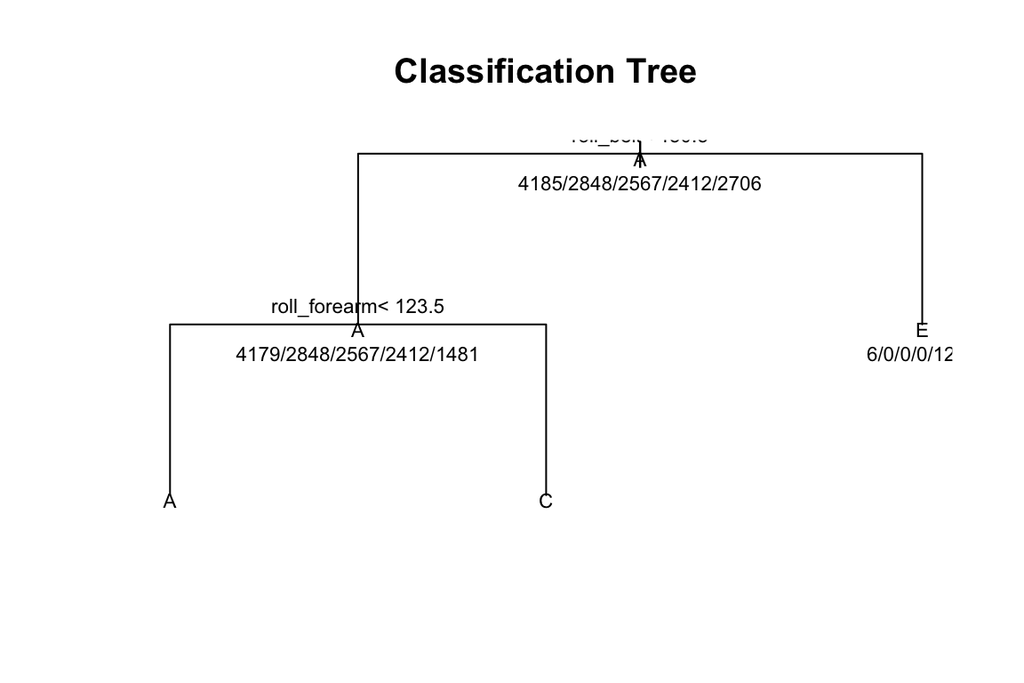

```r
plot(modFit$finalModel, uniform=TRUE, main="Classification Tree")
text(modFit$finalModel, use.n=TRUE, all=TRUE, cex=.7)
ac <- confusionMatrix(predict(modFit,train95), train95$classe)$overall[[1]]
```

We see that the classification tree is not performing exceptionnally well (in sample Accuracy = 0.43), failing to predict any B or D class. We carry on testing other models. As the computational time of training Random Forest and Boosting model is too long my little computer, we use Linear disciminant analysis (lda) model.

```r
modFit2 <- train(classe ~ ., data = train95, method="lda")
ac2 <- confusionMatrix(predict(modFit2,train95), train95$classe)$overall[[1]]
```

This model has good results, with an in-sample Accuracy of = 0.786. Generally, better results can be obtain when combining predictors. had we been able to train different predictors, we could have used a simple blending of model to test if it gives better results. We therefore choose model 2, using Linear disciminant analysis.

#### 5. Estimation of out of sample error

We want to estimate the out of sample error for the chosen model. We use the **testing**, making sure to apply the same transformations.

```r
testing <- testing[,colnames(testing)[colSums(is.na(testing),na.rm = FALSE) == 0]]
testing <- testing[,colnames(testing)[colSums(testing == "",na.rm = FALSE) == 0]]
testing <- testing[,-1]
test95 <- testing[, c(colnames(testing)[1:7], var95, "classe")]
table(predict(modFit2,test95),test95$classe)
```

```
##
##        A    B    C    D    E
##   A 1185  143   10    3    0
##   B  178  667   75   12    0
##   C   32  133  645  134    0
##   D    0    6  112  592  133
##   E    0    0   13   63  768
```

```r
ac2_test <- confusionMatrix(predict(modFit2,test95), test95$classe)$overall[[1]]
```

The accuracy on the testing set is rather good = 0.787.

### Validation

We use the **validation** set to make predictions.

```r
dataValid <- dataValid[,colnames(dataValid)[colSums(is.na(dataValid),na.rm = FALSE) == 0]]
dataValid <- dataValid[,colnames(dataValid)[colSums(dataValid == "",na.rm = FALSE) == 0]]
dataValid <- dataValid[,-1]
valid95 <- dataValid[, c(colnames(dataValid)[1:7], var95, "problem_id")]
predict(modFit2,valid95)
```

```
##  [1] B B B A A D D C A A B C B A E E A B B B
## Levels: A B C D E
```